# Case Study 1 - Cyclistic

Miguel Cuervo

2025-11-05

#1 Ask (Preguntar) El objetivo de este caso de estudio es responder a la pregunta: “¿Cómo usan los ciclistas ocasionales y los miembros anuales las bicicletas de manera diferente?” El objetivo es ayudar al equipo de marketing a diseñar una estrategia para convertir a los ciclistas ocasionales en miembros.

#2 Prepare (Preparar) Usando los archivos de viaje del Q1_2019 y Q1_2020, se cargan las librerías necesarias y los dos archivos CSV en dataframes separados, combinándolos posteriormente.

```r
#------PREPARAR------
#cargar libreria principal
library(tidyverse)
library(lubridate)

#importar datasets en environment
#cargar archivos csv con variable propia
trips_2019_Q1 <- read_csv("~/DATA ANALYSIS/PROYECT A/Divvy Tripdata (19-20 Q1)/Divvy_Trips_2019_Q1.csv")
trips_2020_Q1 <- read_csv("~/DATA ANALYSIS/PROYECT A/Divvy Tripdata (19-20 Q1)/Divvy_Trips_2020_Q1.csv")
#combinar dataframes en uno solo
all_trips <- bind_rows(trips_2019_Q1,trips_2020_Q1)
```

#3 Process (Procesar) Se crean nuevas columnas para duración de viajes y viajes por día según tipo de usuarios. Se filtran los viajes con tiempos menores a 1 minuto y mayores a 24 horas. Se filtran columnas innecesarias con información irrelevante para nuestro análisis.

```r
#------PROCESAR------
#crear columnas ride length y day of week con mutate
all_trips_v2 <- all_trips %>%
  #calculo de duracion del viaje en segundos
  mutate(ride_lenght_sec = difftime(ended_at,started_at, units="secs"),
         #calculo de dia de semana dom = 1 sab =7
         day_of_week = wday(started_at, week_start = 1))

#filtrar viajes muy cortos o mayores a 24hrs
all_trips_clean <- all_trips_v2 %>%
  filter(ride_lenght_sec>0,ride_lenght_sec>60,ride_lenght_sec<86400)
all_trips_clean <- all_trips_clean %>%
  mutate(ride_lenght_min=ride_lenght_sec/60)
  glimpse(all_trips_clean)
```

```
## Rows: 418,901
## Columns: 28
## $ trip_id            <dbl> NA, NA, NA, NA, NA, NA, NA, NA, NA, NA, NA, NA, NA,…
## $ start_time         <dttm> NA, NA, NA, NA, NA, NA, NA, NA, NA, NA, NA, NA, NA…
## $ end_time           <dttm> NA, NA, NA, NA, NA, NA, NA, NA, NA, NA, NA, NA, NA…
## $ bikeid             <dbl> NA, NA, NA, NA, NA, NA, NA, NA, NA, NA, NA, NA, NA,…
## $ tripduration       <dbl> NA, NA, NA, NA, NA, NA, NA, NA, NA, NA, NA, NA, NA,…
## $ from_station_id    <dbl> NA, NA, NA, NA, NA, NA, NA, NA, NA, NA, NA, NA, NA,…
## $ from_station_name  <chr> NA, NA, NA, NA, NA, NA, NA, NA, NA, NA, NA, NA, NA,…
## $ to_station_id      <dbl> NA, NA, NA, NA, NA, NA, NA, NA, NA, NA, NA, NA, NA,…
## $ to_station_name    <chr> NA, NA, NA, NA, NA, NA, NA, NA, NA, NA, NA, NA, NA,…
## $ usertype           <chr> NA, NA, NA, NA, NA, NA, NA, NA, NA, NA, NA, NA, NA,…
## $ gender             <chr> NA, NA, NA, NA, NA, NA, NA, NA, NA, NA, NA, NA, NA,…
## $ birthyear          <dbl> NA, NA, NA, NA, NA, NA, NA, NA, NA, NA, NA, NA, NA,…
## $ ride_id            <chr> "EACB19130B0CDA4A", "8FED874C809DC021", "789F3C21E4…
## $ rideable_type      <chr> "docked_bike", "docked_bike", "docked_bike", "docke…
## $ started_at         <dttm> 2020-01-21 20:06:59, 2020-01-30 14:22:39, 2020-01-…
## $ ended_at           <dttm> 2020-01-21 20:14:30, 2020-01-30 14:26:22, 2020-01-…
## $ start_station_name <chr> "Western Ave & Leland Ave", "Clark St & Montrose Av…
## $ start_station_id   <dbl> 239, 234, 296, 51, 66, 212, 96, 96, 212, 38, 117, 1…
## $ end_station_name   <chr> "Clark St & Leland Ave", "Southport Ave & Irving Pa…
## $ end_station_id     <dbl> 326, 318, 117, 24, 212, 96, 212, 212, 96, 100, 632,…
## $ start_lat          <dbl> 41.9665, 41.9616, 41.9401, 41.8846, 41.8856, 41.889…
## $ start_lng          <dbl> -87.6884, -87.6660, -87.6455, -87.6319, -87.6418, -…
## $ end_lat            <dbl> 41.9671, 41.9542, 41.9402, 41.8918, 41.8899, 41.884…
## $ end_lng            <dbl> -87.6674, -87.6644, -87.6530, -87.6206, -87.6343, -…
## $ member_casual      <chr> "member", "member", "member", "member", "member", "…
## $ ride_lenght_sec    <drtn> 451 secs, 223 secs, 171 secs, 529 secs, 332 secs, …
## $ day_of_week        <dbl> 2, 4, 4, 1, 4, 5, 5, 5, 5, 5, 2, 3, 3, 4, 2, 2, 2, …
## $ ride_lenght_min    <drtn> 7.516667 secs, 3.716667 secs, 2.850000 secs, 8.816…
```

```r
  #remover columnas con PII
  all_trips_final <- all_trips_clean %>%
    select (-trip_id,
            -start_time,
            -end_time,
            -bikeid,
            -tripduration,
            -from_station_id,
            -from_station_name,
            -to_station_id,
            -to_station_name,
            -usertype,
            -gender,
            -birthyear)
```

#4 Analyze (Analizar) Se calcula el promedio de viajes por cada tipo de usuario, además del tiempo máximo por viaje y viajes por día.

```r
#------ANALIZAR------
  #calcular promedio de viaje por tipo de miembro
avg_ride_length = all_trips_final %>%
    group_by(member_casual) %>%

 #calcular promedio de duracion en minutos
    summarise(average_ride_min = mean(ride_lenght_min),

 #calcular viaje maximo
    max_ride_min = max(ride_lenght_min))

    #calcular viajes por dia
    rides_per_day <- all_trips_clean %>%
    group_by(member_casual, day_of_week) %>%
    summarise(number_of_rides = n())%>%
    arrange(member_casual, day_of_week)
```

#5 Visualize (Visualizar) Se generan dos gráficos, el primero exponiendo la duración promedio en minutos por viaje según tipo de usuario. Y el segundo, analizando el número total de viajes por tipo de usuario dependiendo del día de la semana.

```
## Defaulting to continuous.
```

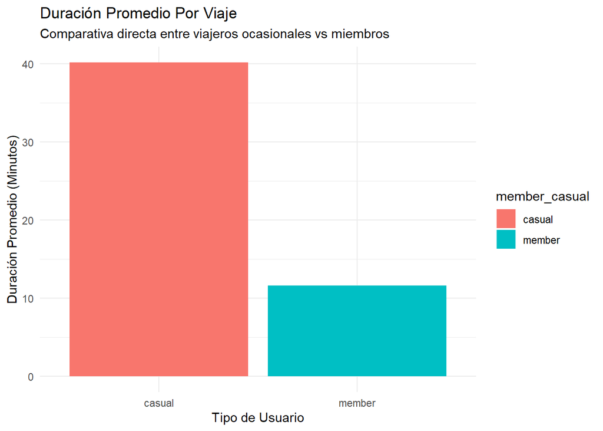

```r
#------VISUALIZACION------
  library(ggplot2)
  #Gráfico 1: Duración promedio del viaje (en minutos)
    ggplot(data = avg_ride_length, aes(x = member_casual, y = average_ride_min, fill = member_casual)) +
      geom_col() +
      labs(
        title = "Duración Promedio Por Viaje",
        subtitle = "Comparativa directa entre viajeros ocasionales vs miembros",
        x = "Tipo de Usuario",
        y = "Duración Promedio (Minutos)") + theme_minimal()
```

```r
    ggsave("avg_ride_length_chart.png")
```

```
## Defaulting to continuous.
```

[figure not shown]

```r
     # Gráfico 2: Número de viajes por día de la semana
    ggplot(data = rides_per_day, aes(x = day_of_week, y = number_of_rides, color = member_casual, group = member_casual)) +
      geom_line(linewidth = 1.5) + # 'linewidth' en lugar de 'size'
      geom_point(size = 3) +
      labs(
        title = "Volumen de Viajes por Día de la Semana",
        subtitle = "Miembros = Semana Laboral (Commute) | Ocasionales = Fin de Semana (Ocio)",
        x = "Día de la Semana (1=Dom, 7=Sáb)",
        y = "Número Total de Viajes" ) +
      scale_color_manual(values = c("casual" = "orange", "member" = "darkblue")) +
      theme_minimal()
```

```r
    ggsave("rides_per_day_chart.png")
```

#6 Act (Actuar) Analizando los datos y las gráficas generadas, nos damos cuenta que los usuarios ocasionales tienen una tendencia a usar el servicio de manera más elevada en fines de semana, registrando paseos largos de aproximadamente 40 minutos. Podemos asumir que los usuarios ocasionales son turistas y gente que sale de paseo en sus tiempos libres y no usan el servicio para asistir a sus trabajos y responsabilidades diarias como los miembros. Como parte final del análisis, sugiero los siguientes 3 acercamientos al problema planteado: 1. Programa de referidos, ofrecer paquetes y precios especiales para viajes en conjunto y turísticos. Utilizar marketing enfocado en paseos largos y atractivos visuales de la ciudad, en lugar de centrarse en la rutina y el traslado diario. 3. Crear un pase o paquete de fin de semana, con precios atractivos para los clientes que no piensan invertir en el servicio completo.